# Temporal chi visualization: Milvus milvus & Aves (iNaturalist)

*▓▓▓▓▓▓▓ ▓▓▓▓▓▓▓, ▓▓▓▓▓▓▓, ▓▓▓▓▓▓▓ ▓▓▓▓▓▓▓ ▓▓▓▓▓▓▓; ▓▓▓▓▓▓▓ ▓▓▓▓▓▓▓, ▓▓▓▓▓▓▓ ▓▓▓▓▓▓▓ ▓▓▓▓▓▓▓, ▓▓▓▓▓▓▓*

[figure not shown]

•••

Last updated: Jun-10-2024, [Carto-Lab Docker](https://gitlab.vgiscience.de/lbsn/tools/jupyterlab) Version 0.14.0

Chi visualization of temporal patterns for ephemeral events. This notebook builds upon a [a previous notebook](https://kartographie.geo.tu-dresden.de/ad/wip/ephemeral_events/html/01_temporal_chi_y.html).

The chi equation requires a specific query (such as all photographs of the Red Kite - Milvus milvus - in Europe from iNaturalist) and a generic query to correct for system-wide sampling effects (such as growing number of iNaturalist contributors). However, different user groups follow different distribution patterns over time and space on geosocial media, which means that it is not easy to select a suitable generic query. Rapacciuolo et al. (2021) emphasize that comparison should be based on user selections from umbrella groups. Here, we explore whether using Chi for Milvus mulvus photographers compared to the umbrella group of "all bird photographers" on iNaturalist in Europe increases or decreases between 2010 to 2022. Given the increasing population of Milvus milvus, we would expect that chi also increases, as it is more likeley that bird photographers can take photographs of the Red Kite.

> Rapacciuolo, G., Young, A., & Johnson, R. (2021). Deriving indicators of biodiversity change from unstructured community‐contributed data. Oikos, 130(8), 1225–1239. https://doi.org/10.1111/oik.08215

For selection of the generic query, we used the [emoji-taxa mappings](https://gitlab.vgiscience.de/lbsn/lbsntransform/-/blob/master/resources/mappings/field_mapping_inaturalist_gbif.py) that I made available for lbsn.vgiscience.org:

The SQL syntax:

```
SELECT *
FROM topical.post t1
WHERE t1.origin_id = 23 and '🐦'=ANY(emoji);
```

This selected **9,147,013** bird photographs from a total number of **53,155,437** nature and plant observations on iNaturalist (2010-2022).  
This dataset is filtered here based on space, used in the chi equation which is then visualized as a bar plot.

# Preparations

•••

```python
OUTPUT = Path.cwd().parents[0] / "out"       # output directory for figures (etc.)
WORK_DIR = Path.cwd().parents[0] / "tmp"     # Working directory
```

```python
OUTPUT.mkdir(exist_ok=True)
(OUTPUT / "figures").mkdir(exist_ok=True)
(OUTPUT / "svg").mkdir(exist_ok=True)
WORK_DIR.mkdir(exist_ok=True)
```

```python
%load_ext autoreload
%autoreload 2
```

```
The autoreload extension is already loaded. To reload it, use:
  %reload_ext autoreload
```

Select `M` for monthly aggregation, `Y` for yearly aggregation

```python
AGG_BASE = "Y"
```

First, define whether to study usercount or postcount

```python
# METRIC = 'user'
METRIC = 'post'
```

```python
metric_col = 'post_hll'
if METRIC == 'user':
    metric_col = 'user_hll'
```

Set global font

```python
plt.rcParams['font.family'] = 'serif'
plt.rcParams['font.serif'] = ['Times New Roman'] + plt.rcParams['font.serif']
```

Set global color

```python
color_flickr = '#F89F5E'
color_inaturalist = '#ED6F53'
```

## Load HLL aggregate data

Load the data from CSV, generated in the previous notebook. Data is stored as aggregate HLL data (postcount, usercount) for each month.

•••

```python
%%time
data_files = {
    "INATURALIST_ALL":INATURALIST_ALL,
    "INATURALIST_ALL_MILVUSRANGE":INATURALIST_ALL_MILVUSRANGE,
    "INATURALIST_ALL_AVES":INATURALIST_ALL_AVES_MILVUSRANGE,
    }
tools.display_file_stats(data_files)
```

| name | INATURALIST_ALL | INATURALIST_ALL_MILVUSRANGE | INATURALIST_ALL_AVES |
| --- | --- | --- | --- |
| size | 989.88 KB | 1.24 MB | 555.78 KB |
| records | 198 | 702 | 198 |

```
CPU times: user 5.01 ms, sys: 613 µs, total: 5.63 ms
Wall time: 5.15 ms
```

```python
pd.read_csv(INATURALIST_ALL_AVES_MILVUSRANGE, nrows=10)
```

|  | year | month | post_hll | user_hll |
| --- | --- | --- | --- | --- |
| 0 | 2007 | 1 | \x138b40026402a204010542096210a116221a811b011c... | \x138b400841136518e12681276228e1296232c355a15c... |
| 1 | 2007 | 2 | \x138b4004a105a30e810f45106211c115c1166519c11a... | \x138b400501296232c33a413ae14b214ca150e155a16c... |
| 2 | 2007 | 3 | \x138b40014101a2066309210a220a810ac20b050be20c... | \x138b4002210282070116611862276229622e8332c33a... |
| 3 | 2007 | 4 | \x138b40016101a203e10463058306c107e1084308810b... | \x138b400421070108640b010fe31342252125e426a127... |
| 4 | 2007 | 5 | \x138b40022102a302e304a5078207a808a10b210c410d... | \x138b4007010fa11ba526a1276228022b012da12e8332... |
| 5 | 2007 | 6 | \x138b40002100a2018102c10321048405230683072107... | \x138b4004830864176318a118e11ba126c4276229622b... |
| 6 | 2007 | 7 | \x138b4000c10141024203e104a204c1058208e30a230e... | \x138b40070108640b010b840c2411e112e1156215c118... |
| 7 | 2007 | 8 | \x138b400121088609810bc30e6114211662178217c218... | \x138b4008640b0111e11502186218a11d031dc1224122... |
| 8 | 2007 | 9 | \x138b4000a1030309810c2313041c0123a424a126a127... | \x138b400701094309640fe3142118a127622e832fe150... |
| 9 | 2007 | 10 | \x138b40040204c308e109430a41164117c119a227e130... | \x138b40042104810fe32da12e832fe13a413da13f413f... |

## Connect hll worker db

```python
DB_USER = "hlluser"
DB_PASS = os.getenv('READONLY_USER_PASSWORD')
# set connection variables
DB_HOST = "127.0.0.1"
DB_PORT = "5452"
DB_NAME = "hllworkerdb"
```

Connect to empty Postgres database running HLL Extension:

```python
DB_CONN = psycopg2.connect(
        host=DB_HOST,
        port=DB_PORT ,
        dbname=DB_NAME,
        user=DB_USER,
        password=DB_PASS
)
DB_CONN.set_session(
    readonly=True)
DB_CALC = tools.DbConn(
    DB_CONN)
CUR_HLL = DB_CONN.cursor()
```

test

# Calculate HLL Cardinality per month and year

Define additional functions for reading and formatting CSV as `pd.DataFrame`

```python
from datetime import datetime

def read_csv_datetime(csv: Path) -> pd.DataFrame:
    """Read CSV with parsing datetime index (months)

        First CSV column: Year
        Second CSV column: Month
    """
    date_cols = ["year", "month"]
    df = pd.read_csv(
        csv, index_col='datetime',
        parse_dates={'datetime':date_cols},
        date_format='%Y %m',
        keep_date_col='False')
    df.drop(columns=date_cols, inplace=True)
    return df

def append_cardinality_df(df: pd.DataFrame, hll_col: str = "post_hll", cardinality_col: str = 'postcount_est'):
    """Calculate cardinality from HLL and append to extra column in df"""
    df[cardinality_col] = df.apply(
        lambda x: hll.cardinality_hll(
           x[hll_col], CUR_HLL),
        axis=1)
    df.drop(columns=[hll_col], inplace=True)
    return df

def filter_fill_time(
        df: pd.DataFrame, min_year: int,
        max_year: int, val_col: str = "postcount_est",
        min_month: str = "01", max_month: str = "01", agg_base: str = None,
        agg_method = None):
    """Filter time values between min - max year and fill missing values"""
    max_day = "01"
    if agg_base is None:
        agg_base = "M"
    elif agg_base == "Y":
        max_month = "12"
        max_day = "31"
    min_date = pd.Timestamp(f'{min_year}-{min_month}-01')
    max_date = pd.Timestamp(f'{max_year}-{max_month}-{max_day}')
    # clip by start and end date
    if not min_date in df.index:
        df.loc[min_date, val_col] = 0
    if not max_date in df.index:
        df.loc[max_date, val_col] = 0
    df.sort_index(inplace=True)
    # mask min and max time
    time_mask = ((df.index >= min_date) & (df.index <= max_date))
    resampled = df.loc[time_mask][val_col].resample(agg_base)
    if agg_method is None:
        series = resampled.sum()
    elif agg_method == "count":
        series = resampled.count()
    elif agg_method == "nunique":
        series = resampled.nunique()
    # fill missing months with 0
    # this will also set the day to max of month
    return series.fillna(0).to_frame()
```

**Select dataset to process below**

Apply functions to all data sets.

```python
def process_dataset(
        dataset: Path = None, metric: str = None, df_post: pd.DataFrame = None,
        min_year: int = None, max_year: int = None, agg_base: str = None) -> pd.DataFrame:
    """Apply temporal filter/pre-processing to all data sets."""
    if metric is None:
        metric = 'post_hll'
        warn(f"Using default value {metric}")
    if metric == 'post_hll':
        cardinality_col = 'postcount_est'
    else:
        cardinality_col = 'usercount_est'
    if min_year is None:
        min_year = 2007
    if max_year is None:
        max_year = 2022
    if df_post is None:
        df_post = read_csv_datetime(dataset)
    df_post = append_cardinality_df(df_post, metric, cardinality_col)
    return filter_fill_time(df_post, min_year, max_year, cardinality_col, agg_base=agg_base)
```

```python
%%time
df_post = process_dataset(INATURALIST_ALL_AVES_MILVUSRANGE, agg_base=AGG_BASE, metric='post_hll')
```

```
CPU times: user 12.5 ms, sys: 5.89 ms, total: 18.4 ms
Wall time: 49.3 ms
```

```python
df_post.head(5)
```

| datetime | postcount_est |
| --- | --- |
| 2007-12-31 | 1358.0 |
| 2008-12-31 | 1300.0 |
| 2009-12-31 | 1950.0 |
| 2010-12-31 | 2464.0 |
| 2011-12-31 | 2184.0 |

```python
%%time
df_user = process_dataset(INATURALIST_ALL_AVES_MILVUSRANGE, metric=metric_col, agg_base=AGG_BASE)
```

```
CPU times: user 14.7 ms, sys: 1.62 ms, total: 16.3 ms
Wall time: 42.5 ms
```

```python
df_user.head(5)
```

| datetime | postcount_est |
| --- | --- |
| 2007-12-31 | 1358.0 |
| 2008-12-31 | 1300.0 |
| 2009-12-31 | 1950.0 |
| 2010-12-31 | 2464.0 |
| 2011-12-31 | 2184.0 |

# Visualize Cardinality

Define plot function.

```python
def bar_plot_time(
        df: pd.DataFrame, ax: Axes, color: str,
        label: str, val_col: str = "postcount_est") -> Axes:
    """Matplotlib Barplot with time axis formatting

    If "significant" in df columns, applies different colors to fill/edge
    of non-significant values.
    """
    if color is None:
        # colors = sns.color_palette("vlag", as_cmap=True, n_colors=2)
        # color_rgba = colors([1.0])[0]
        # color = mcolor.rgb2hex((color_rgba), keep_alpha=True)
        color = color_inaturalist
    color_significant = color
    color_significant_edge = "white"
    if "significant" in df.columns:
        colors_bar = {True: color, False: "white"}
        color_significant = df['significant'].replace(colors_bar)
        colors_edge = {True: "white", False: "black"}
        color_significant_edge = df['significant'].replace(colors_edge)
    ax = df.set_index(
        df.index.map(lambda s: s.strftime('%Y'))).plot.bar(
            ax=ax, y=val_col, color=color_significant, width=1.0,
            label=label, edgecolor=color_significant_edge, linewidth=0.5, alpha=1.0)
    return ax

def plot_time(
        df: Tuple[pd.DataFrame, pd.DataFrame], title, color = None, filename = None,
        output = OUTPUT, legend: str = "Postcount", val_col: str = None,
        trend: bool = None, seasonal: bool = None, residual: bool = None,
        agg_base: str = None):
    """Create dataframe(s) time plot"""
    x_ticks_every = 12
    fig_x = 15.7
    fig_y = 4.27
    font_mod = False
    x_label = "Month"
    linewidth = 3
    if agg_base and agg_base == "Y":
        x_ticks_every = 1
        fig_x = 3
        fig_y = 1.5
        font_mod = True
        x_label = "Year"
        linewidth = 1
    fig, ax = plt.subplots()
    fig.set_size_inches(fig_x, fig_y)
    ylabel = f'{legend}'
    if val_col is None:
        val_col = f'{legend.lower()}_est'
    ax = bar_plot_time(
        df=df, ax=ax, color=color, val_col=val_col, label=legend)
    # x axis ticker formatting
    tick_loc = mticker.MultipleLocator(x_ticks_every)
    ax.xaxis.set_major_locator(tick_loc)
    ax.tick_params(axis='x', rotation=45, length=0)
    ax.yaxis.set_major_formatter(mticker.StrMethodFormatter('{x:,.0f}'))
    ax.set(xlabel=x_label, ylabel=ylabel)
    ax.spines["left"].set_linewidth(0.25)
    ax.spines["bottom"].set_linewidth(0.25)
    ax.spines["top"].set_linewidth(0)
    ax.spines["right"].set_linewidth(0)
    ax.yaxis.set_tick_params(width=0.5)
    # remove legend
    ax.get_legend().remove()
    ax.set_title(title)
    ax.set_xlim(-0.5,len(df)-0.5)
    if font_mod:
        for item in (
            [ax.xaxis.label, ax.title, ax.yaxis.label] +
             ax.get_xticklabels() + ax.get_yticklabels()):
                item.set_fontsize(8)
    if any([trend, seasonal, residual]):
        # seasonal decompose
        decomposition = sm.tsa.seasonal_decompose(
            df[val_col], model='additive')
        # plot trend part only
        if trend:
            plt.plot(list(decomposition.trend), color='black',
                label="Trend", linewidth=linewidth, alpha=0.8)
        if seasonal:
            plt.plot(list(decomposition.seasonal), color='black', linestyle='dotted',
                label="Seasonal", linewidth=1, alpha=0.8)
        if residual:
            plt.plot(list(decomposition.resid), color='black', linestyle='dashed',
                label="Residual", linewidth=1, alpha=0.8)
        # trend.plot(ax=ax)
    # store figure to file
    if filename:
        fig.savefig(
            output / "figures" / f"{filename}.png", dpi=300, format='PNG',
            bbox_inches='tight', pad_inches=1, facecolor="white")
        # also save as svg
        fig.savefig(
            output / "svg" / f"{filename}.svg", format='svg',
            bbox_inches='tight', pad_inches=1, facecolor="white")
```

```python
def load_and_plot(
        dataset: Path = None, metric: str = None, src_ref: str = "flickr", colors: cm.colors.ListedColormap = None,
        agg_base: str = None, trend: bool = None, return_df: bool = None, df_post: pd.DataFrame = None,):
    """Load data and plot"""
    if metric is None:
        metric = 'post_hll'
    if metric == 'post_hll':
        metric_label = 'postcount'
    else:
        metric_label = 'usercount'
    if colors is None:
        # colors = sns.color_palette("vlag", as_cmap=True, n_colors=2)
        # colors = colors([1.0])
        colors = color_inaturalist
    df = process_dataset(dataset, metric=metric, agg_base=agg_base, df_post=df_post)
    plot_time(
        df, legend=metric_label.capitalize(), color=colors,
        title=f'{src_ref.capitalize().replace(" ", "_")} {metric_label} over time',
        filename=f"temporal_{metric_label}_{src_ref}_absolute", trend=trend, agg_base=agg_base)
    if return_df:
        return df
```

```python
colors = sns.color_palette("vlag", as_cmap=True, n_colors=2)
```

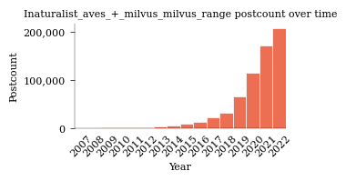

```python
load_and_plot(INATURALIST_ALL_AVES_MILVUSRANGE, src_ref=f"iNaturalist Aves + Milvus milvus range", agg_base=AGG_BASE, trend=False, metric=metric_col)
```

Plot iNaturalist Milvus range

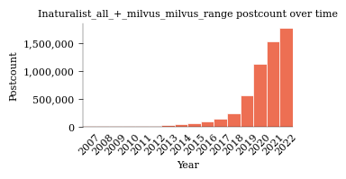

```python
load_and_plot(INATURALIST_ALL_MILVUSRANGE, src_ref=f"iNaturalist All + Milvus milvus range", agg_base=AGG_BASE, trend=False, metric=metric_col)
```

Repeat for all iNaturalist data

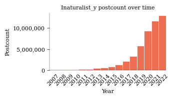

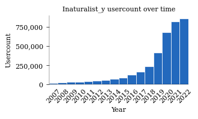

```python
load_and_plot(INATURALIST_ALL, src_ref=f"inaturalist_{AGG_BASE}", agg_base=AGG_BASE, trend=False)
load_and_plot(INATURALIST_ALL, src_ref=f"inaturalist_{AGG_BASE}", metric="user_hll", colors=colors([0.0]), agg_base=AGG_BASE, trend=False)
```

### Prepare Chi

This is adapted from [notebook three](https://ad.vgiscience.org/sunset-sunrise-paper/03_chimaps.html) of the original publication.

First, define the input parameter:

```python
DOF = 1
CHI_CRIT_VAL = 3.84
CHI_COLUMN: str = f"{METRIC}count_est"
```

```python
def calc_norm(
    df_expected: pd.DataFrame,
    df_observed: pd.DataFrame,
    chi_column: str = CHI_COLUMN):
    """Fetch the number of data points for the observed and
    expected dataset by the relevant column
    and calculate the normalisation value
    """
    v_expected = df_expected[chi_column].sum()
    v_observed = df_observed[chi_column].sum()
    norm_val = (v_expected / v_observed)
    return norm_val
```

```python
def chi_calc(x_observed: float, x_expected: float, x_normalized: float) -> pd.Series:
    """Apply chi calculation based on observed (normalized) and expected value"""
    value_observed_normalised = x_observed * x_normalized
    a = value_observed_normalised - x_expected
    b = math.sqrt(x_expected)
    # native division with division by zero protection
    chi_value = a / b if b else 0
    return chi_value

def apply_chi_calc(
        df: pd.DataFrame, norm_val: float,
        chi_column: str = CHI_COLUMN, chi_crit_val: float = CHI_CRIT_VAL):
    """Calculate chi-values based on two GeoDataFrames (expected and observed values)
    and return new grid with results"""
    # lambda: apply function chi_calc() to each item
    df['chi_value'] = df.apply(
        lambda x: chi_calc(
           x[chi_column],
           x[f'{chi_column}_expected'],
           norm_val),
        axis=1)
    # add significant column, default False
    df['significant'] = False
    # calculate significance for both negative and positive chi_values
    df.loc[np.abs(df['chi_value'])>chi_crit_val, 'significant'] = True
```

# Visualize Chi for subqueries

## Proportion of "Milvus milvus" observations vs. all iNaturalist observations

First load the worldwide dataset

```python
src = Path.cwd().parents[0] / "00_data" / "milvus" / "observations-350501.csv"
```

```python
load_inat_kwargs = {
    "filepath_or_buffer":src,
    "index_col":'datetime',
    "parse_dates":{'datetime':["observed_on"]},
    "date_format":'%Y-%m-%d',
    "keep_date_col":'False',
    "usecols":["id", "observed_on", "user_id"]
}
df = pd.read_csv(**load_inat_kwargs)
```

```python
df.drop(columns=['observed_on'], inplace=True)
```

```python
df.head()
```

| datetime | id | user_id |
| --- | --- | --- |
| 2010-05-22 | 7793 | 446 |
| 2011-01-01 | 9495 | 351 |
| 2011-01-01 | 9496 | 351 |
| 2011-04-17 | 14694 | 654 |
| 2011-10-05 | 50134 | 4130 |

```python
val_col = "id"
agg_method = "count"
metric_label="observations"
if METRIC == "user":
    val_col = "user_id"
    agg_method = "nunique"
    metric_label="observers"
```

```python
df_milvus = filter_fill_time(
    df, 2007, 2022, val_col=val_col, agg_base=AGG_BASE, agg_method=agg_method)
```

```python
df_milvus.rename(columns={val_col: metric_label}, inplace=True)
```

```python
src_ref="iNaturalist Milvus milvus"
```

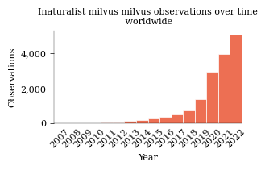

```python
plot_time(
        df_milvus, legend=metric_label.capitalize(),
        title=f'{src_ref.capitalize()} {metric_label} over time\n worldwide', val_col=metric_label,
        filename=f"temporal_iNaturalist_milvusmilvus_absolute", trend=False, agg_base=AGG_BASE)
```

```python
df_milvus.sum()
```

```
observations    15896
dtype: int64
```

## Limit to Milvus milvus range

```python
CRS_WGS = "epsg:4326" # WGS1984
CRS_PROJ = "esri:54009" # Mollweide
```

```python
load_inat_kwargs["usecols"] = ["id", "user_id", "observed_on", "longitude", "latitude"]
df = pd.read_csv(**load_inat_kwargs)
```

```python
load_inat_kwargs['usecols'] = None
```

```python
df.dropna(subset=['longitude', 'latitude'], inplace=True)
```

```python
df
```

| datetime | id | observed_on | user_id | latitude | longitude |
| --- | --- | --- | --- | --- | --- |
| 2010-05-22 | 7793 | 2010-05-22 | 446 | 52.440923 | -3.953872 |
| 2011-01-01 | 9495 | 2011-01-01 | 351 | 51.185595 | -1.212616 |
| 2011-01-01 | 9496 | 2011-01-01 | 351 | 51.280226 | -0.925083 |
| 2011-04-17 | 14694 | 2011-04-17 | 654 | 51.814146 | -0.192910 |
| 2011-08-03 | 50348 | 2011-08-03 | 4130 | 50.406329 | 8.873863 |
| ... | ... | ... | ... | ... | ... |
| 2023-07-02 | 178281936 | 2023-07-02 | 5483063 | 47.661184 | 8.854844 |
| 2023-07-29 | 178325879 | 2023-07-29 | 1859910 | 51.047883 | 10.996382 |
| 2013-06-09 | 178326364 | 2013-06-09 | 6476964 | 51.454250 | -0.884408 |
| 2023-08-12 | 178333330 | 2023-08-12 | 4228845 | 47.961332 | 16.769473 |
| 2023-08-13 | 178333356 | 2023-08-13 | 186190 | 45.129853 | 7.695633 |

20106 rows × 5 columns

Intersect with the spatial range that is available as kml from iNaturalist.

```python
import geopandas as gp
milvus_range = gp.read_file(
    OUTPUT/ 'Milvusmilvus_range.gpkg', layer='Milvus milvus')
```

```python
gdf = gp.GeoDataFrame(
    df, geometry=gp.points_from_xy(df.longitude, df.latitude), crs=CRS_WGS)
```

Intersect, keep only observations within range.

```python
gdf_overlay = gp.overlay(
    gdf, milvus_range,
    how='intersection')
```

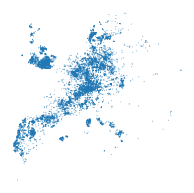

```python
ax = gdf_overlay.plot(markersize=.1)
ax.axis('off')
plt.show()
```

Calculate chi

```python
gdf_overlay
```

|  | id | observed_on | user_id | latitude | longitude | Name | Description | geometry |
| --- | --- | --- | --- | --- | --- | --- | --- | --- |
| 0 | 7793 | 2010-05-22 | 446 | 52.440923 | -3.953872 |  |  | POINT (-3.95387 52.44092) |
| 1 | 9495 | 2011-01-01 | 351 | 51.185595 | -1.212616 |  |  | POINT (-1.21262 51.18559) |
| 2 | 9496 | 2011-01-01 | 351 | 51.280226 | -0.925083 |  |  | POINT (-0.92508 51.28023) |
| 3 | 14694 | 2011-04-17 | 654 | 51.814146 | -0.192910 |  |  | POINT (-0.19291 51.81415) |
| 4 | 50348 | 2011-08-03 | 4130 | 50.406329 | 8.873863 |  |  | POINT (8.87386 50.40633) |
| ... | ... | ... | ... | ... | ... | ... | ... | ... |
| 19067 | 178281936 | 2023-07-02 | 5483063 | 47.661184 | 8.854844 |  |  | POINT (8.85484 47.66118) |
| 19068 | 178325879 | 2023-07-29 | 1859910 | 51.047883 | 10.996382 |  |  | POINT (10.99638 51.04788) |
| 19069 | 178326364 | 2013-06-09 | 6476964 | 51.454250 | -0.884408 |  |  | POINT (-0.88441 51.45425) |
| 19070 | 178333330 | 2023-08-12 | 4228845 | 47.961332 | 16.769473 |  |  | POINT (16.76947 47.96133) |
| 19071 | 178333356 | 2023-08-13 | 186190 | 45.129853 | 7.695633 |  |  | POINT (7.69563 45.12985) |

19072 rows × 8 columns

```python
gdf_overlay['datetime'] = pd.to_datetime(gdf_overlay["observed_on"], format=load_inat_kwargs.get("date_format"))
gdf_overlay.set_index('datetime', inplace=True)
gdf_cleaned = tools.drop_cols_except(gdf_overlay, [val_col], inplace=False)
```

```python
df_milvus_range = filter_fill_time(
    gdf_cleaned, 2007, 2022, val_col=val_col, agg_base=AGG_BASE, agg_method=agg_method)
```

```python
df_milvus_range.rename(columns={val_col: metric_label}, inplace=True)
```

```python
src_ref="iNaturalist Milvus milvus"
```

```python
df_milvus_range.sum()
```

```
observations    14988
dtype: int64
```

Conclusion: Majority of observations is within the spatial range kml (16k total vs 15k in spatial range)

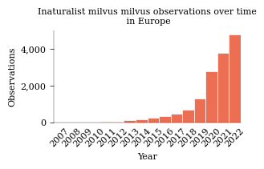

```python
plot_time(
        df_milvus_range, legend=metric_label.capitalize(),
        title=f'{src_ref.capitalize()} {metric_label} over time\n in Europe', val_col=metric_label,
        filename=f"temporal_iNaturalist_milvusmilvus_absolute", trend=False, agg_base=AGG_BASE)
```

### Calculate chi: Proportion to all iNaturalist photographs

First: Calculate chi based on all iNaturalist observations within Europe

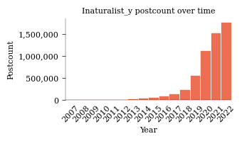

```python
df_expected = load_and_plot(
    INATURALIST_ALL_MILVUSRANGE, src_ref=f"inaturalist_{AGG_BASE}",
    agg_base=AGG_BASE, trend=False, return_df=True, metric=metric_col)
```

```python
norm_val = calc_norm(
    df_expected.rename(columns={f'{METRIC}count_est':metric_label}, inplace=False),
    df_milvus_range, chi_column = metric_label)
print(norm_val)
```

```
383.41553242594074
```

```python
df_expected.rename(columns={f'{METRIC}count_est':f'{metric_label}_expected'}, inplace=True)
```

```python
merge_cols = [f'{METRIC}count_est']
df_expected_observed_inat = df_expected.merge(
    df_milvus_range[metric_label],
    left_index=True, right_index=True)
```

```python
%%time
apply_chi_calc(
    df=df_expected_observed_inat,
    norm_val=norm_val, chi_column=metric_label)
```

```
CPU times: user 977 µs, sys: 577 µs, total: 1.55 ms
Wall time: 1.53 ms
```

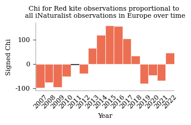

```python
plot_time(
    df_expected_observed_inat, legend="Signed Chi", val_col="chi_value",
    title=f'Chi for Red kite {metric_label} proportional to \nall iNaturalist {metric_label} in Europe over time',
    filename=f"temporal_chi_inaturalist_{metric_label}_milvus_{AGG_BASE}_{metric_label}", trend=False,
    seasonal=False, residual=False, agg_base=AGG_BASE)
```

We can observe a proportional increase of Red kite observations between 2012 and 2019.

### Calculate chi: Proportion of Milvus milvus vs. "Aves" tax class observations

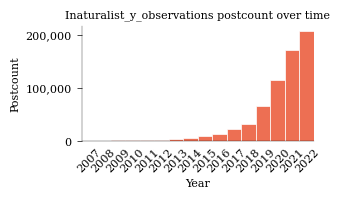

```python
df_expected = load_and_plot(
    INATURALIST_ALL_AVES_MILVUSRANGE, src_ref=f"inaturalist_{AGG_BASE}_{metric_label}",
    agg_base=AGG_BASE, trend=False, return_df=True, metric=metric_col)
```

```python
norm_val = calc_norm(
    df_expected.rename(columns={f'{METRIC}count_est':metric_label}, inplace=False),
    df_milvus_range, chi_column = metric_label)
print(norm_val)
```

```
44.15238857752869
```

```python
df_expected.rename(columns={f'{METRIC}count_est':f'{metric_label}_expected'}, inplace=True)
```

```python
merge_cols = [f'{METRIC}count_est']
df_expected_observed_inat = df_expected.merge(
    df_milvus_range[metric_label],
    left_index=True, right_index=True)
```

```python
%%time
apply_chi_calc(
    df=df_expected_observed_inat,
    norm_val=norm_val, chi_column=metric_label)
```

```
CPU times: user 870 µs, sys: 521 µs, total: 1.39 ms
Wall time: 1.38 ms
```

```python
df_expected_observed_inat
```

| datetime | observations_expected | observations | chi_value | significant |
| --- | --- | --- | --- | --- |
| 2007-12-31 | 1358.0 | 9 | -26.067872 | True |
| 2008-12-31 | 1300.0 | 18 | -14.013308 | True |
| 2009-12-31 | 1950.0 | 18 | -26.161420 | True |
| 2010-12-31 | 2464.0 | 37 | -16.728112 | True |
| 2011-12-31 | 2184.0 | 60 | 9.953148 | True |
| 2012-12-31 | 2770.0 | 60 | -2.296311 | False |
| 2013-12-31 | 4136.0 | 132 | 26.311141 | True |
| 2014-12-31 | 6645.0 | 199 | 26.268493 | True |
| 2015-12-31 | 10395.0 | 277 | 18.000058 | True |
| 2016-12-31 | 13774.0 | 379 | 25.218878 | True |
| 2017-12-31 | 22362.0 | 485 | -6.340083 | True |
| 2018-12-31 | 33030.0 | 702 | -11.197346 | True |
| 2019-12-31 | 66383.0 | 1311 | -32.987588 | True |
| 2020-12-31 | 114893.0 | 2797 | 25.375454 | True |
| 2021-12-31 | 171350.0 | 3756 | -13.319731 | True |
| 2022-12-31 | 206762.0 | 4748 | 6.319490 | True |

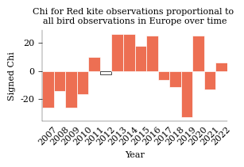

```python
plot_time(
    df_expected_observed_inat, legend="Signed Chi", val_col="chi_value",
    title=f'Chi for Red kite {metric_label} proportional to \nall bird {metric_label} in Europe over time',
    filename=f"temporal_chi_inaturalist_{metric_label}_milvus_{AGG_BASE}", trend=False,
    seasonal=False, residual=False, agg_base=AGG_BASE)
```

## Proportion of "Aves" tax class observations vs. all iNaturalist observations

- both queries limited to Milvus milvus range in Europe

### Expected: All iNaturalist

- limited to Europe

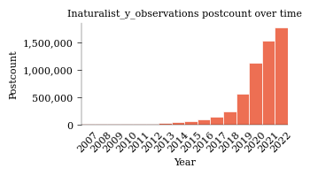

```python
df_expected = load_and_plot(
    INATURALIST_ALL_MILVUSRANGE, src_ref=f"inaturalist_{AGG_BASE}_{metric_label}",
    agg_base=AGG_BASE, trend=False, return_df=True, metric=metric_col)
```

### Observed: All Aves tax class observations

- limited to Europe

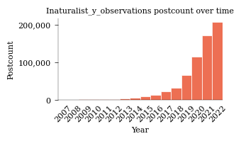

```python
df_observed = load_and_plot(
    INATURALIST_ALL_AVES_MILVUSRANGE, src_ref=f"inaturalist_{AGG_BASE}_{metric_label}",
    agg_base=AGG_BASE, trend=False, return_df=True, metric=metric_col)
```

```python
norm_val = calc_norm(
    df_expected.rename(columns={f'{METRIC}count_est':metric_label}), df_observed.rename(columns={f'{METRIC}count_est':metric_label}), chi_column = metric_label)
print(norm_val)
```

```
8.683913708375897
```

```python
df_observed.head()
```

| datetime | postcount_est |
| --- | --- |
| 2007-12-31 | 1358.0 |
| 2008-12-31 | 1300.0 |
| 2009-12-31 | 1950.0 |
| 2010-12-31 | 2464.0 |
| 2011-12-31 | 2184.0 |

```python
df_expected.rename(columns={f'{METRIC}count_est':f'{metric_label}_expected'}, inplace=True)
df_observed.rename(columns={f'{METRIC}count_est':metric_label}, inplace=True)
```

```python
merge_cols = [f'{METRIC}count_est']
df_expected_observed_inat = df_expected.merge(
    df_observed[metric_label],
    left_index=True, right_index=True)
```

```python
df_expected_observed_inat.head()
```

| datetime | observations_expected | observations |
| --- | --- | --- |
| 2007-12-31 | 15728.0 | 1358.0 |
| 2008-12-31 | 16534.0 | 1300.0 |
| 2009-12-31 | 20439.0 | 1950.0 |
| 2010-12-31 | 21873.0 | 2464.0 |
| 2011-12-31 | 23299.0 | 2184.0 |

```python
%%time
apply_chi_calc(
    df=df_expected_observed_inat,
    norm_val=norm_val, chi_column=metric_label)
```

```
CPU times: user 952 µs, sys: 572 µs, total: 1.52 ms
Wall time: 1.51 ms
```

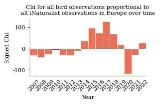

```python
plot_time(
    df_expected_observed_inat, legend="Signed Chi", val_col="chi_value",
    title=f'Chi for all bird {metric_label} proportional to \nall iNaturalist {metric_label} in Europe over time',
    filename=f"temporal_chi_inaturalist_{metric_label}_milvus_{AGG_BASE}", trend=False,
    seasonal=False, residual=False, agg_base=AGG_BASE)
```

## Create Release File

Create a release file that contains ipynb notebooks, HTML, figures, svg and python converted files.

Make sure that 7z is available (`apt-get install p7zip-full`)

```python
!cd .. && git config --system --add safe.directory '*' \
    && RELEASE_VERSION=$(git describe --tags --abbrev=0) \
    && 7z a -tzip -mx=9 out/release_$RELEASE_VERSION.zip \
    md/* py/* out/*.csv resources/* out/svg/* \
    out/figures/* notebooks/*.ipynb \
    CHANGELOG.md README.md jupytext.toml nbconvert.tpl conf.json pyproject.toml \
    -x!py/__pycache__ -x!py/modules/__pycache__ -x!py/modules/.ipynb_checkpoints \
    -y > /dev/null
```

```python
!RELEASE_VERSION=$(git describe --tags --abbrev=0) && ls -alh ../out/release_$RELEASE_VERSION.zip
```

```
-rw-r--r-- 1 root root 18M Jul 11 08:38 ../out/release_v1.0.1.zip
```

# Create notebook HTML

```python
!jupyter nbconvert --to html_toc \
    --output-dir=../resources/html/ ./10_milvus_chi.ipynb \
    --template=../nbconvert.tpl \
    --ExtractOutputPreprocessor.enabled=False >&- 2>&-
```